# Transitional Justice Research Project

Farrah J. Israel

# Introduction

My final project sits at the center of what is known as Transitional Justice research which I will be working on with Professor Bates this summer through a summer research grant called L&S Honors Summer Research Apprenticeship. Within Transitional Justice research is this idea of the global “justice cascade” which is the global shift toward holding leaders accountable for human rights abuses. Scholars such as Kathryn Sikkink argue that the modern “justice cascade” has been propelled not only by states but also by human rights organizations. The goal of this overall project is to determine whether atrocities from certain countries and/or certain kinds of atrocities are more/less likely to make its way all the way up to be recognized by large human rights organizations (such as the UN, Amnesty International, and the Red Cross). The data that I am working with for this final project was collected by previous Research Assistants and will serve as the foundation for the work I will be continuing this summer.

This final project specifically, will explore whether a country that has higher democracy levels, has greater access to justice. Access to justice can be defined as the ability of ordinary people to use legal systems to resolve disputes and seek protection. It varies dramatically across countries, and political scientists constantly debate what explains this variation. **My research question is: Do higher levels of liberal democracy improve access to justice? I hypothesize that countries with stronger democratic institutions will have higher access to justice scores.** This question matters because access to justice is a main component when it comes to rule of law and human rights. In theory, democracies are meant to constrain state power, reduce arbitrary violence, and create institutions for resolving disputes. If democracy actually improves legal access, that has implications for how we think about international development, rule of law promotion, and human rights policy. It also connects to broader patterns visible in the data. Ratifiers of the Rome Statute, for example, tend to be a lot more democratic than countries that do not ratify the Rome Statute.

# Data

This analysis uses country‑year observational data. This makes the research design **cross‑sectional** with repeated observations, not experimental. The **main dependent variable is the Access to Justice Index (v2xcl_acjst).** It is a continuous measure from 0-1, low to high, where higher values indicate stronger access to justice. The data was calculated and obtained from the Varieties of Democracy (V-Dem) dataset which is based on the expert‑survey question, “Do citizens enjoy secure and effective access to justice?”

The key **independent variable is the Liberal Democracy Score (v2x_libdem).** It is also a continuous measure from 0-1, low to high, where higher values indicate stronger Liberal Democracy. The data was also calculated and obtained from the Varieties of Democracy (V-Dem) dataset. For this variable, the data comes from the question: “To what extent is the ideal of liberal democracy achieved?”

Additional variables used for descriptive context include continent (categorical), total atrocities (count), and Rome Statute ratification (binary). Atrocities are measured using conflict‑event data that record killings, disappearances, and other forms of political violence.

# Hypothesis

**I hypothesize that countries with stronger democratic institutions will have higher access to justice scores.** Democracies are designed to protect the rights of individuals, have independent legal institutions, and constrain state power. All of these attributes of a democracy should also translate into greater ability for citizens to seek access to justice.

Here, the **null hypothesis is that liberal democracy has no relationship with access to justice.** This means that any observed positive association between the variables is due to chance. The **alternative hypothesis is that countries with stronger democracy have higher access to justice scores, reflecting a true, non-random relationship.**

My hypothesis will be supported if the coefficient on Liberal Democracy is positive and statistically significant. In other words, if more democratic countries systematically score higher on Access to Justice. A coefficient near zero or a p-value above 0.05 would undermine the hypothesis.

To visualize the main outcome variable, the main plot shows the distribution of Access to Justice scores across all country-year observations.

Here is the codebook that goes into more detail about the data: https://drive.google.com/file/d/1rBsOnN3ph3bW2U9ybJmleacqfomuf_k4/view?usp=sharing

#### Rename Columns

```
## # A tibble: 4,374 × 15
##    Country      Year COWcode Intervention Investigation Prosecute
##    <chr>       <dbl>   <dbl>        <dbl>         <dbl>     <dbl>
##  1 Afghanistan  1998     700            0             0         0
##  2 Afghanistan  1999     700            0             0         0
##  3 Afghanistan  2000     700            0             0         0
##  4 Afghanistan  2001     700            0             0         0
##  5 Afghanistan  2002     700            0             0         0
##  6 Afghanistan  2003     700            0             0         0
##  7 Afghanistan  2004     700            0             0         0
##  8 Afghanistan  2005     700            0             0         0
##  9 Afghanistan  2006     700            0             0         0
## 10 Afghanistan  2007     700            0             0         0
## # ℹ 4,364 more rows
## # ℹ 9 more variables: Cooperation_Investigation <dbl>,
## #   Cooperation_Prosecution <dbl>, Liberal_Democracy <dbl>,
## #   Access_to_Justice <dbl>, Civil_Society <dbl>, Atrocities <dbl>,
## #   ICC_Involvement <dbl>, ICC_ratification <dbl>, p5 <dbl>
```

#### Add Continent Column

```
## # A tibble: 4,374 × 17
##    Country      Year COWcode Intervention Investigation Prosecute
##    <chr>       <dbl>   <dbl>        <dbl>         <dbl>     <dbl>
##  1 Afghanistan  1998     700            0             0         0
##  2 Afghanistan  1999     700            0             0         0
##  3 Afghanistan  2000     700            0             0         0
##  4 Afghanistan  2001     700            0             0         0
##  5 Afghanistan  2002     700            0             0         0
##  6 Afghanistan  2003     700            0             0         0
##  7 Afghanistan  2004     700            0             0         0
##  8 Afghanistan  2005     700            0             0         0
##  9 Afghanistan  2006     700            0             0         0
## 10 Afghanistan  2007     700            0             0         0
## # ℹ 4,364 more rows
## # ℹ 11 more variables: Cooperation_Investigation <dbl>,
## #   Cooperation_Prosecution <dbl>, Liberal_Democracy <dbl>,
## #   Access_to_Justice <dbl>, Civil_Society <dbl>, Atrocities <dbl>,
## #   ICC_Involvement <dbl>, ICC_ratification <dbl>, p5 <dbl>, Continent <chr>,
## #   P5_label <chr>
```

#### Sort by One Country Per Row

```
## # A tibble: 162 × 14
##    Country   COWcode Intervention Investigation Prosecute Cooperation_Investig…¹
##    <chr>       <dbl>        <dbl>         <dbl>     <dbl>                  <dbl>
##  1 Afghanis…     700       0.667         0.852      0.111                  0.593
##  2 Albania       339       0             0          0                      0
##  3 Algeria       615       0             0          0                      0
##  4 Angola        540       0             0          0                      0
##  5 Argentina     160       0             0          0                      0
##  6 Australia     900       0.0741        0.0370     0                      0
##  7 Austria       305       0             0          0                      0
##  8 Azerbaij…     373       0.0741        0.0741     0                      0
##  9 Bahrain       692       0.296         0.0741     0                      0
## 10 Banglade…     771       0.148         0.222      0.111                  0
## # ℹ 152 more rows
## # ℹ abbreviated name: ¹Cooperation_Investigation
## # ℹ 8 more variables: Cooperation_Prosecution <dbl>, Liberal_Democracy <dbl>,
## #   Access_to_Justice <dbl>, Civil_Society <dbl>, Atrocities <dbl>,
## #   ICC_Involvement <dbl>, ICC_ratification <dbl>, p5 <dbl>
```

## Plot visualizing main outcome of interest

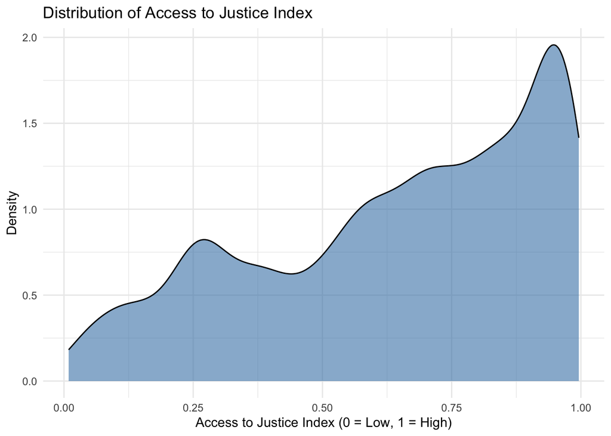

## Average Atrocities by Continent

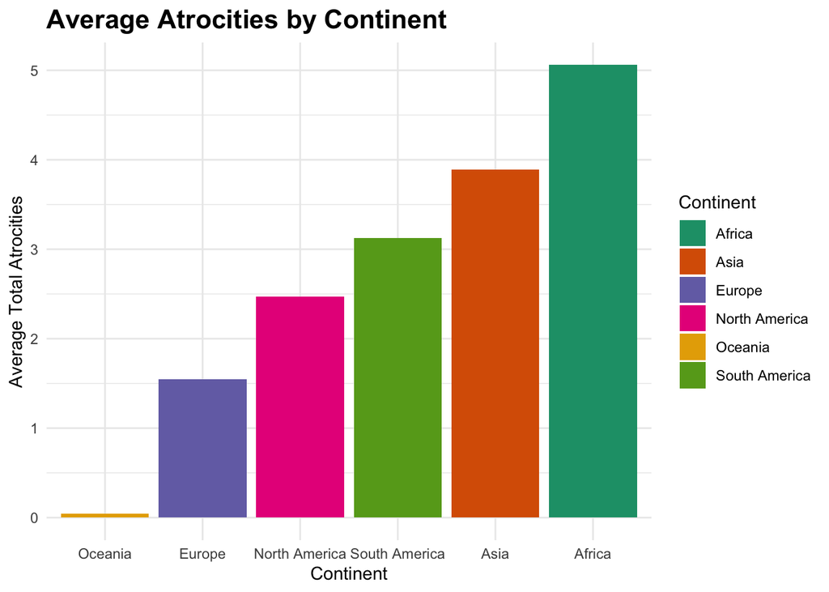

The bar chart below provides descriptive context for why access to justice matters: Africa and Asia show the highest average levels of political violence (measured as logged atrocity counts). Why might this be? This motivates the central analysis, which examines whether stronger democratic institutions are associated with greater access to justice across all regions.

## Access to Justice by Continent

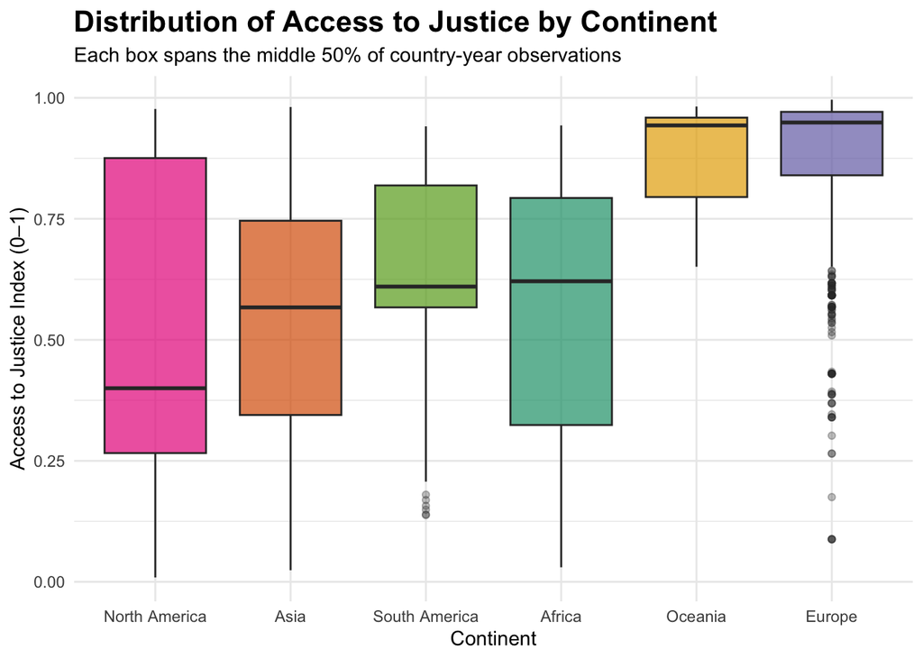

The boxplot reveals clear regional variation in access to justice, with Europe and Oceania with the highest median Access to Justice scores while Asia and Africa show lower medians and wider spreads. It is surprising that Asia and Africa do not sit at the bottom of the distribution despite scoring high on atrocities in the barplot above. There are many reasons for this…maybe atrocities are often concentrated in specific countries or time periods within a region, while other countries in the same continent maintain relatively functional legal institutions that pull the regional average upward.

# Results

### Plot Main Analysis

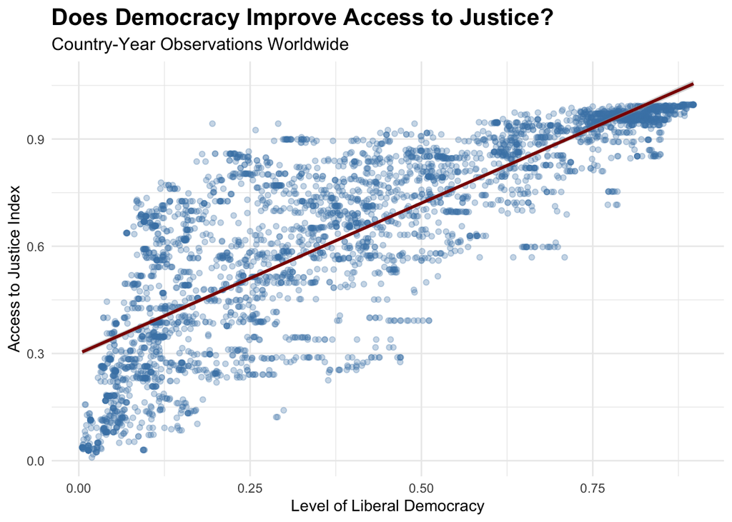

### Another Way to View Plot Main Analysis — Country Averages

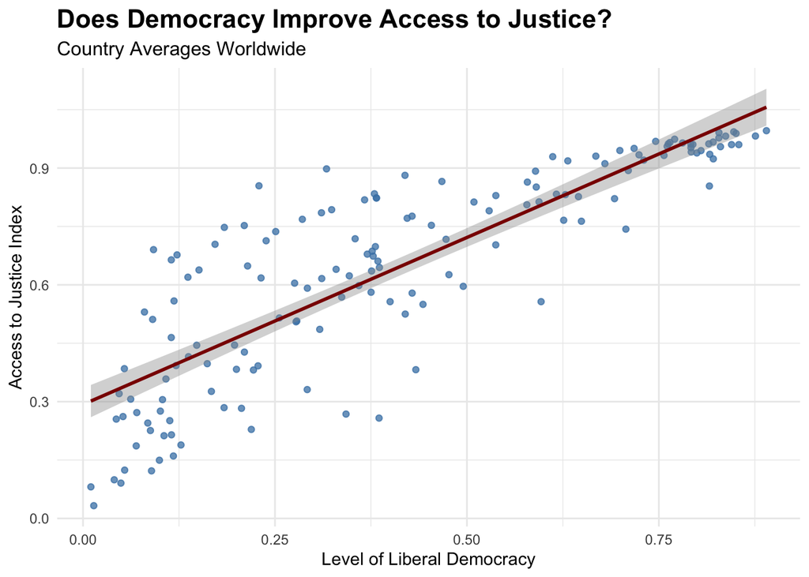

The two scatterplots (same graph, just viewed differently), strongly suggest that as liberal democracy increases, access to justice also tends to increase. The red line slopes upward, confirming this. While there is some scatter, the pattern is overall positive.

### Add the confounder to test (GDP data obtained from World Bank)

```
## ──────────────────────────────────────────────────────── Delimiter: "," chr
## (4): Country Name, Country Code, Indicator Name, Indicator Code dbl (65): 1960,
## 1961, 1962, 1963, 1964, 1965, 1966, 1967, 1968, 1969, 1970, ... lgl (2): 2025,
## ...71
```

```
## # A tibble: 6 × 16
##   Country      Year COW_Code Intervention Investigation Prosecute
##   <chr>       <dbl>    <dbl>        <dbl>         <dbl>     <dbl>
## 1 Afghanistan  2002      700            0             0         0
## 2 Afghanistan  2003      700            0             0         0
## 3 Afghanistan  2004      700            0             0         0
## 4 Afghanistan  2005      700            0             0         0
## 5 Afghanistan  2006      700            0             0         0
## 6 Afghanistan  2007      700            0             0         0
## # ℹ 10 more variables: Cooperation_Investigation <dbl>,
## #   Cooperation_Prosecution <dbl>, Liberal_Democracy <dbl>,
## #   Access_to_Justice <dbl>, Civil_Society <dbl>, Atrocities <dbl>,
## #   ICC_Involvement <dbl>, ICC_Ratification <dbl>, P5_Member <dbl>,
## #   gdp_per_capita <dbl>
```

## Bivariate Regression

| Variable | Coefficient | Std. Error | P-value |
| --- | --- | --- | --- |
| Intercept | 0.317 | 0.005 | 0 |
| Liberal Democracy | 0.810 | 0.009 | 0 |

## Multivariate Regression

| Variable | Coefficient | Std. Error | P-value |
| --- | --- | --- | --- |
| Intercept | 0.215 | 0.015 | 0 |
| Liberal Democracy | 0.760 | 0.012 | 0 |
| Log GDP per Capita | 0.015 | 0.002 | 0 |

The multivariate regression predicts access to justice using liberal democracy and GDP per capita. The intercept of **0.215 (Standard Error = 0.015)** means that when both predictors are held at zero, the predicted access to justice score is 0.215 — a theoretical baseline that anchors the regression line. The main finding is the Liberal Democracy coefficient of **0.760 (Standard Error = 0.012, p < 0.001),** meaning that holding GDP constant, a one-unit increase in the liberal democracy index is associated with a 0.76-point increase in the access to justice score. The small standard error indicates this estimate is precisely measured and stable across samples. The GDP per capita coefficient of **0.015 (Standard Error = 0.002, p < 0.001)** on the log scale means that a one-unit increase in log GDP per capita is associated with a 0.015-point increase in access to justice. All three p-values round to zero, meaning none of these relationships are statistically consistent with a null effect. The democracy coefficient (0.760) is roughly 50 times the size of the GDP coefficient (0.015), confirming that democracy is the stronger predictor of the two.

### Another visual - taking into account confounders

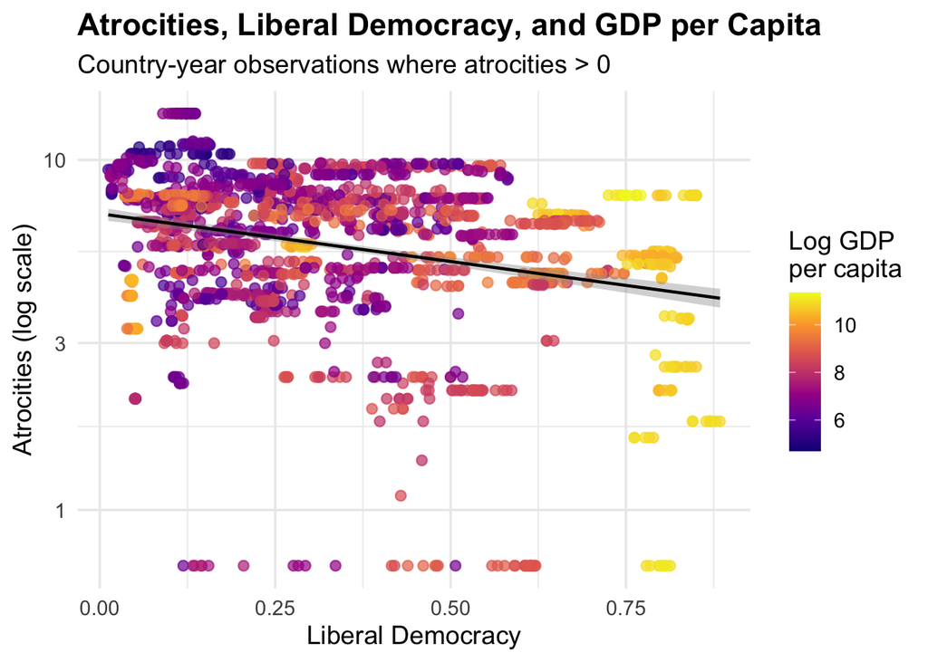

# Results Write up

The scatterplot titled “Does Democracy Improve Access to Justice” shows the relationship between Liberal Democracy Score (x-axis) and Access to Justice Index (y-axis). The first scatterplot is across all country-year observations and the second one has the took the average from the countries by year. Both scatterplots reveal a positive association. The association is, as liberal democracy increases, access to justice also increases. The confidence band is narrow, showing that the trend is not driven by outliers, but rather a consistent trend. The OLS regression line slopes upward across the Liberal Democracy index. The scatterplot with the countries averaged reinforces this pattern. All in all, the visual evidence is consistent with the hypothesis that stronger democratic institutions are associated with greater access to justice.

To assess whether GDP per capita acts as a confounder, I merged the dataset from Professor Bates with the World Bank GDP data and added log GDP per capita as a second predictor. When merging the datasets, I simply added GDP per capita as an additional column. I choose to do this because I was curious to see if economic development was a potential confounder. This is because wealthier countries, for example, tend to be more democratic and better able to fund courts, legal aid, and judicial oversight which would ultimately result in a higher access to justice index. Comparing the two regressions shows a meaningful shift from the bivariate model, where the democracy coefficient is 0.810 and then drops to 0.760 in the multivariate model after controlling for GDP. This shows that GDP per capita is a weak confounder, because while it decreased, it did not decrease by much. In other words, the shift is small enough that the overwhelming majority of the democracy-justice association cannot be attributed to differences in GDP per capita. Controlling for GDP therefore confirms that democracy’s relationship with access to justice is not simply a proxy for wealth

Despite the strength of the association, the results should not be interpreted causally. The research design is observational and cross-sectional with repeated observations, which means that countries are compared to one another rather than randomly assigned different levels of democracy. There are several confounders that could bias the relationship. For example, countries with stronger bureaucratic and administrative capacity tend to have ore effective courts and legal institutions and have more stable democratic systems. These would ultimately result in a higher access to justice index. Moreover, because both variables are constructed from the same V-Dem expert-survey methodology, shared measurement processes may artificially inflate the correlation. For those reasons, the coefficient should be interpreted as a strong descriptive association, not a causal effect of democratization on legal access.

# Conclusion

Overall, the visualization and regression results provide strong evidence that countries with higher levels of liberal democracy tend to exhibit much greater access to justice. This is clear support for the hypothesis that democratic institutions and legal protections move together. At the same time, however, the analysis is still limited due to the observational nature of the data, the possibility of omitted variables such as economic development or state capacity, and the fact that both variables came from the same expert survey infrastructure (V-Dem). With additional time or resources, the analysis could be strengthened by incorporating a broader set of controls and using alternative data sources to reduce common-method bias.

# Code Printout

```r
library(tidyverse)
library(ggplot2)
library(dplyr)
load("RAData.RData")
RAdata <- RAdata |>
  rename(
    Country = country,
    Year = year,
    Intervention = intervention,
    Investigation = investigation,
    Prosecute = prosecute,
    Liberal_Democracy = v2x_libdem,
    Access_to_Justice = v2xcl_acjst,
    Civil_Society = v2xcs_ccsi,
    Atrocities = log_atrocities,
    ICC_Involvement = involvementm,
    Cooperation_Investigation = stateCinv,
    Cooperation_Prosecution = stateCpros)
RAdata
Africa <- c("Algeria","Angola","Benin","Botswana","Burkina Faso","Burundi","Cameroon",
  "Cape Verde","Central African Republic","Chad","Comoros","Cote d'Ivoire",
  "Democratic Republic of Congo","Egypt","Equatorial Guinea","Eritrea","Ethiopia",
  "Gambia","Ghana","Guinea","Kenya","Lesotho","Liberia","Libya","Madagascar","Malawi",
  "Mali","Mauritania","Mauritius","Morocco","Mozambique","Namibia","Niger","Nigeria",
  "Republic of Congo","Rwanda","Senegal","Sierra Leone","Somalia","South Africa",
  "South Sudan","Sudan","Tanzania","Togo","Tunisia","Uganda","Zambia","Zimbabwe")
North_America <- c("Canada","United States","Mexico","Costa Rica","Cuba",
  "Dominican Republic","El Salvador","Grenada","Guatemala","Haiti","Honduras",
  "Jamaica","Nicaragua","Panama")
South_America <- c("Argentina","Bolivia","Brazil","Chile","Colombia","Ecuador",
  "Paraguay","Peru","Suriname","Uruguay","Venezuela")
Asia <- c("Afghanistan","Azerbaijan","Bahrain","Bangladesh","Bhutan","Cambodia","China",
  "Cyprus","Georgia","Hong Kong","India","Indonesia","Iran","Iraq","Israel","Japan",
  "Jordan","Kazakhstan","Kuwait","Lebanon","Malaysia","Mongolia","Myanmar","Nepal",
  "North Korea","Pakistan", "Philippines","Qatar","Saudi Arabia","Singapore",
  "South Korea","Sri Lanka","Syria","Taiwan","Thailand","Timor-Leste","Turkey",
  "United Arab Emirates","Uzbekistan","Vietnam","Yemen")
Europe <- c("Albania","Austria","Belarus","Belgium","Bosnia and Herzegovina","Bulgaria",
  "Croatia","Czech Republic","Denmark","Finland","France","Germany","Greece","Hungary",
  "Iceland","Ireland","Italy","Kosovo","Latvia","Liechtenstein","Lithuania","Malta",
  "Moldova","Netherlands","Northern Ireland","Norway","Poland","Portugal","Romania",
  "Russia","Serbia","Slovakia","Slovenia","Spain","Sweden","Switzerland","Ukraine",
  "United Kingdom","Yugoslavia")
Oceania <- c("Australia","Fiji","Marshall Islands","Micronesia","New Zealand","Palau","Vanuatu")

RAdata <- RAdata |>
  mutate(
    Continent = case_when(
      Country %in% Africa ~ "Africa",
      Country %in% North_America ~ "North America",
      Country %in% South_America ~ "South America",
      Country %in% Asia ~ "Asia",
      Country %in% Europe ~ "Europe",
      Country %in% Oceania ~ "Oceania",
      TRUE ~ NA_character_),
    P5_label = ifelse(p5 == 1, "P5 Member", "Non-P5"))

continent_colors <- c(
  "Africa" = "#1b9e77",
  "Asia" = "#d95f02",
  "Europe" = "#7570b3",
  "North America" = "#e7298a",
  "South America" = "#66a61e",
  "Oceania" = "#e6ab02")

RAdata
RAdata_country_avg <- RAdata |>
  select(-Year) |>
  group_by(Country) |>
  summarize(across(where(is.numeric), mean, na.rm = TRUE))
RAdata_country_avg
RAdata <- RAdata |>
  filter(!is.na(Access_to_Justice),
         is.finite(Access_to_Justice))

ggplot(RAdata, aes(x = Access_to_Justice)) +
  geom_density(fill = "steelblue", alpha = 0.6) +
  labs(
    title = "Distribution of Access to Justice Index",
    x = "Access to Justice Index (0 = Low, 1 = High)",
    y = "Density"
  ) +
  theme_minimal()

RAdata |>
  drop_na(Continent, Atrocities) |>
  group_by(Continent) |>
  summarize(
    avg_atrocities = mean(Atrocities, na.rm = TRUE),
    n = n()) |>
  arrange(desc(avg_atrocities)) |>
  ggplot(aes(x = reorder(Continent, avg_atrocities),
             y = avg_atrocities,
             fill = Continent)) +
  geom_col() +
  scale_fill_manual(values = continent_colors) +
  labs(
    title = "Average Atrocities by Continent",
    x = "Continent",
    y = "Average Total Atrocities") +
  theme_minimal() +
  theme(
    plot.title = element_text(size = 16, face = "bold"))
RAdata |>
  drop_na(Continent, Access_to_Justice) |>
  ggplot(aes(x = reorder(Continent, Access_to_Justice, FUN = median),
             y = Access_to_Justice,
             fill = Continent)) +
  geom_boxplot(alpha = 0.7, outlier.alpha = 0.3) +
  scale_fill_manual(values = continent_colors) +
  labs(
    title    = "Distribution of Access to Justice by Continent",
    subtitle = "Each box spans the middle 50% of country-year observations",
    x = "Continent",
    y = "Access to Justice Index (0–1)") +
  theme_minimal() +
  theme(
    plot.title = element_text(size = 16, face = "bold"),
    plot.subtitle = element_text(size = 11),
    legend.position = "none")
RAdata |>
  filter(!is.na(Liberal_Democracy), !is.na(Access_to_Justice)) |>
  ggplot(aes(x = Liberal_Democracy, y = Access_to_Justice)) +
  geom_point(alpha = 0.3, color = "steelblue") +
  geom_smooth(method = "lm", se = TRUE, color = "darkred") +
  labs(
    title    = "Does Democracy Improve Access to Justice?",
    subtitle = "Country-Year Observations Worldwide",
    x = "Level of Liberal Democracy",
    y = "Access to Justice Index"
  ) +
  theme_minimal() +
  theme(
    plot.title    = element_text(size = 16, face = "bold"),
    plot.subtitle = element_text(size = 12)
  )
RAdata_country_avg |>
  filter(!is.na(Liberal_Democracy), !is.na(Access_to_Justice)) |>
  ggplot(aes(x = Liberal_Democracy, y = Access_to_Justice)) +
  geom_point(alpha = 0.75, color = "steelblue") +
  geom_smooth(method = "lm", se = TRUE, color = "darkred") +
  labs(
    title    = "Does Democracy Improve Access to Justice?",
    subtitle = "Country Averages Worldwide",
    x = "Level of Liberal Democracy",
    y = "Access to Justice Index"
  ) +
  theme_minimal() +
  theme(
    plot.title    = element_text(size = 16, face = "bold"),
    plot.subtitle = element_text(size = 12))
load("RAData.RData")

wb_raw <- read_csv(
  unz("API_NY.GDP.PCAP.CD_DS2_en_csv_v2_245.zip",
      "API_NY.GDP.PCAP.CD_DS2_en_csv_v2_245.csv"),
  skip = 4)

wb_long <- wb_raw |>
  select(`Country Name`, `1998`:`2024`) |>
  pivot_longer(
    cols      = `1998`:`2024`,
    names_to  = "year",
    values_to = "gdp_per_capita") |>
  mutate(year = as.numeric(year)) |>
  rename(country = `Country Name`)

merged <- RAdata |>
  mutate(country = case_when(
    country == "Syria" ~ "Syrian Arab Republic",
    country == "Taiwan" ~ "Taiwan, China",
    country == "Yemen" ~ "Yemen, Rep.",
    country == "Vietnam" ~ "Viet Nam",
    country == "Russia" ~ "Russian Federation",
    country == "South Korea" ~ "Korea, Rep.",
    country == "North Korea" ~ "Korea, Dem. People's Rep.",
    country == "Turkey" ~ "Turkiye",
    country == "Egypt" ~ "Egypt, Arab Rep.",
    country == "Iran" ~ "Iran, Islamic Rep.",
    country == "Slovakia" ~ "Slovak Republic",
    country == "Czech Republic" ~ "Czechia",
    country == "Cape Verde" ~ "Cabo Verde",
    country == "Gambia" ~ "Gambia, The",
    country == "Hong Kong" ~ "Hong Kong SAR, China",
    country == "Micronesia" ~ "Micronesia, Fed. Sts.",
    country == "Republic of Congo" ~ "Congo, Rep.",
    country == "Democratic Republic of Congo" ~ "Congo, Dem. Rep.",
    country == "None" ~ NA_character_,
    TRUE ~ country)) |>
  filter(!is.na(country)) |>
  left_join(wb_long, by = c("country", "year")) |>
  rename(
    Country = country,
    Year = year,
    COW_Code = COWcode,
    Intervention = intervention,
    Investigation = investigation,
    Prosecute = prosecute,
    Cooperation_Investigation  = stateCinv,
    Cooperation_Prosecution = stateCpros,
    Liberal_Democracy = v2x_libdem,
    Access_to_Justice = v2xcl_acjst,
    Civil_Society = v2xcs_ccsi,
    Atrocities = log_atrocities,
    ICC_Involvement = involvementm,
    ICC_Ratification = ICC_ratification,
    P5_Member = p5) |>
  drop_na()

save(merged, file = "RAData_merged.RData")

merged |> head()
library(broom)

fit <- lm(Access_to_Justice ~ Liberal_Democracy, data = merged)
fit |>
  tidy() |>
  select(term, estimate, std.error, p.value) |>
  mutate(
    term = recode(term,
      "Liberal_Democracy" = "Liberal Democracy",
      "(Intercept)" = "Intercept"),
    across(where(is.numeric), round, 3)) |>
  knitr::kable(col.names = c("Variable", "Coefficient", "Std. Error", "P-value"))
fit_2 <- lm(Access_to_Justice ~ Liberal_Democracy + log(gdp_per_capita), data = merged)

tidy(fit_2) |>
  select(term, estimate, std.error, p.value) |>
  mutate(
    term = recode(term,
      "Liberal_Democracy" = "Liberal Democracy",
      "log(gdp_per_capita)" = "Log GDP per Capita",
      "(Intercept)" = "Intercept"),
    across(where(is.numeric), round, 3)) |>
  knitr::kable(col.names = c("Variable", "Coefficient", "Std. Error", "P-value"))
merged |>
  filter(Atrocities > 0) |>
  ggplot(aes(
    x = Liberal_Democracy,
    y = Atrocities,
    color = log(gdp_per_capita)
  )) +
  geom_point(alpha = 0.7, size = 2.2) +
  geom_smooth(method = "lm", color = "black", se = TRUE, linewidth = 0.8) +
  scale_y_log10() +
  scale_color_viridis_c(option = "plasma", name = "Log GDP\nper capita") +
  labs(
    title = "Atrocities, Liberal Democracy, and GDP per Capita",
    subtitle = "Country-year observations where atrocities > 0",
    x = "Liberal Democracy",
    y = "Atrocities (log scale)") +
  theme_minimal(base_size = 14) +
  theme(
    plot.title = element_text(face = "bold"),
    legend.position = "right")
```